# Vertebrate Array Summary

```r
library(ggplot2)
library(tidyverse)
library(gridExtra)
library(minfi)
```

# Mappability of array

There are two files provided by Horvath to select probes that are mappable to the mouse genome. The unique mappability file contains probes that are unqiue matches to the mouse genome. The ambiguous files are not exact matches and the probe sequences can bind to more than one site on the mouse genome. Below the plot shows the density distribtuiion of all the probes on the array, the ambiguous probes and the uniqye probes. It is clear that the unique probes are clear consistent across all samples.

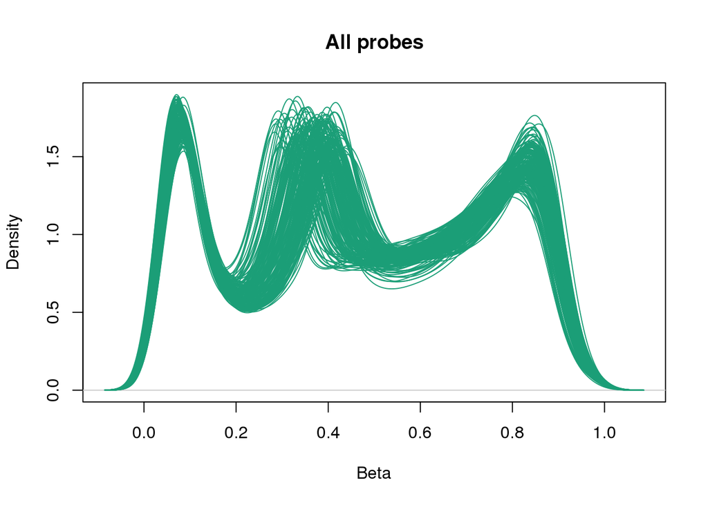

```r
load("/gpfs/ts0/projects/Research_Project-191406/Aisha/data/Array/AllProbesRaw_QCd.rdat")
amb_probe_map <- read_csv("/gpfs/ts0/projects/Research_Project-191406/Horvath/MammalianArrayNormalizationTools/mappabilityData/HorvathMammalChip_SpeciesGenomeCoordsAmbiguous_v1.1.csv", col_types = cols(.default = "c"))
amb_probe_map <- amb_probe_map[, c('probeID','MusMusculus')]
amb_probe_map <- as.data.frame(amb_probe_map[!is.na(amb_probe_map$MusMusculus),]) #24,048

uniq_probe_map <- read_csv("/gpfs/ts0/projects/Research_Project-191406/Horvath/MammalianArrayNormalizationTools/mappabilityData/HorvathMammalChip_SpeciesGenomeCoordsUnique_v1.1.csv", col_types = cols(.default = "c"))
uniq_probe_map  <- uniq_probe_map [, c('probeID','MusMusculus')]
uniq_probe_map <- as.data.frame(uniq_probe_map[!is.na(uniq_probe_map$MusMusculus),]) #23,633

amb_betas <- subsetByLoci(RGset_all, include=amb_probe_map$probeID)
uniq_betas <- subsetByLoci(RGset_all, include=uniq_probe_map$probeID)

densityPlot(RGset_all, main = "All probes")
```

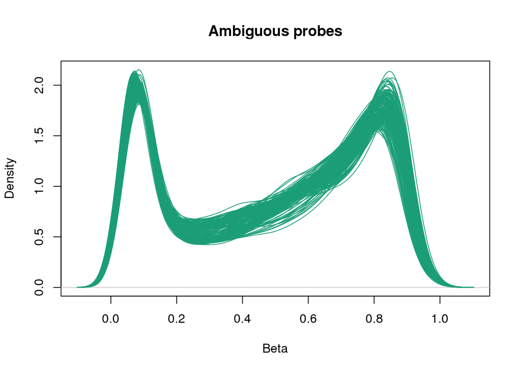

```r
densityPlot(amb_betas,main = "Ambiguous probes")
```

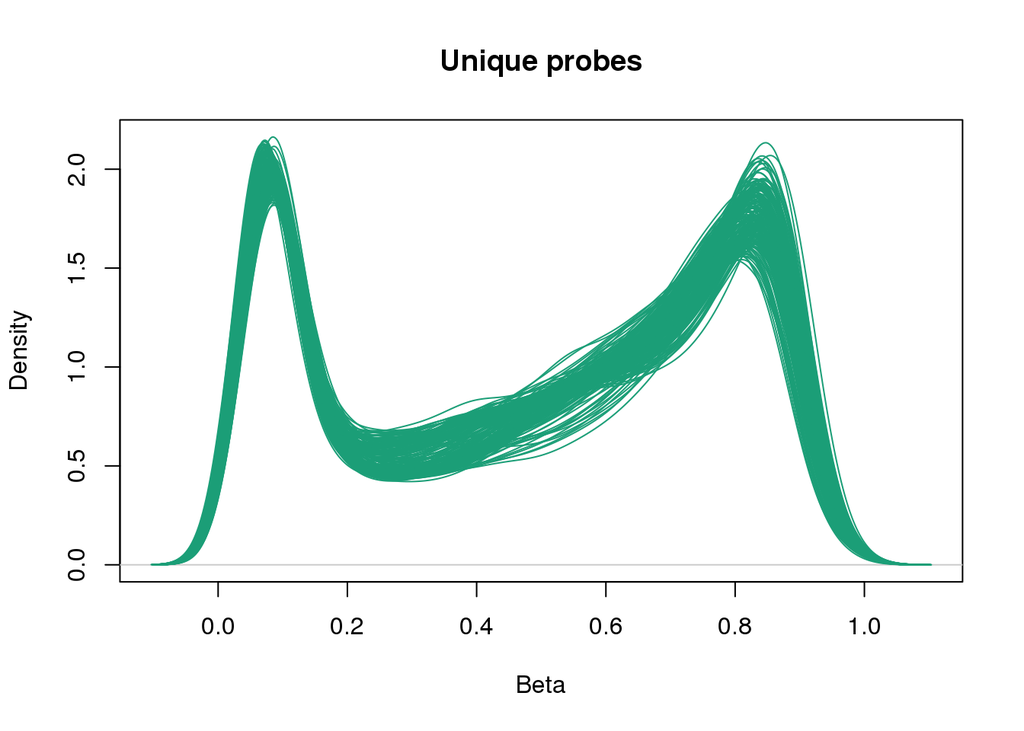

```r
densityPlot(uniq_betas,main = "Unique probes")
```

```r
rm(list=ls())
load("/gpfs/ts0/projects/Research_Project-191406/Aisha/data/Array/Normalised_Data_Sesame.rdat")
probe_mapping_file <- read_csv("/gpfs/ts0/projects/Research_Project-191406/Horvath/MammalianArrayNormalizationTools/mappabilityData/HorvathMammalChip_SpeciesGenomeCoordsUnique_v1.1.csv", col_types = cols(.default = "c"))

#filter for mouse samples
species_mappability_name = "MusMusculus"
species_probes <- probe_mapping_file[, c('probeID','MusMusculus')]
species_probes <- as.data.frame(species_probes[!is.na(species_probes$MusMusculus),]) #23633
species_probes$Chr <- gsub(":.*","",species_probes$MusMusculus)
```

# CpG Islands

This report is a summary for the vertebrate array created by Hovarth’s group. There are 23633 probes that map onto mouse genome. There is a file that summarises which genome version was used for each specieles (MammalianArrayNormalizationTools/mappabilityData/HorvathMammalChip_SpeciesSourcesTaxonomyAndKeys_v1.0.csv). The mouse genome used is genome version 38, Ensembl Release95 (Downloaded 21.9.19). The NCBI Taxid is 10090. Figure below summarises the distribution of cpgs across the mouse genome.

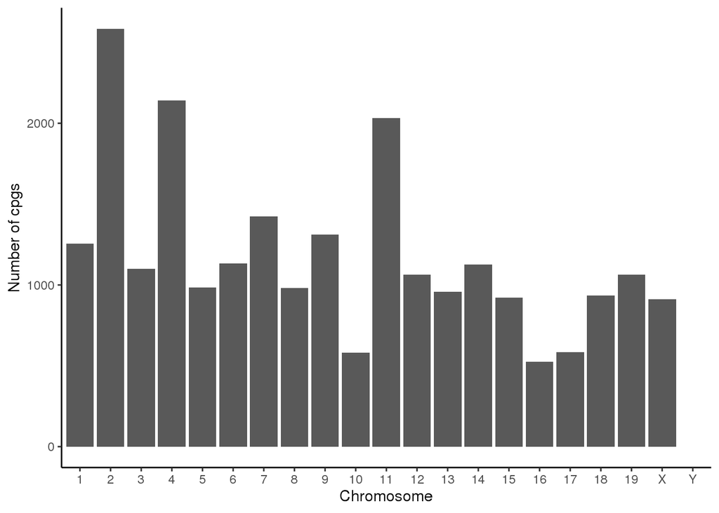

```r
MouseChr <- as.data.frame(table(species_probes$Chr))
MouseChr2 <- MouseChr[c(1:19, 23:24),]
MouseChr2$Var1 <- as.character(MouseChr2$Var1)

chroder <- c("1", '2',  '3',  '4',  '5',  '6',  '7',  '8',  '9',
             '10', '11','12', '13', '14', '15', '16', '17', '18', '19', "X", "Y")

MouseChr2$Var1 <- factor(MouseChr2$Var1, levels = chroder)

ggplot(MouseChr2, aes(MouseChr2$Var1, MouseChr2$Freq))+
  geom_bar(stat = "identity") +
  labs(x = "Chromosome", y = "Number of cpgs") +
  theme_classic()
```

```r
#Plot the proportion of locations of the cpgs across the genome
cpg_loc <- read.csv("/gpfs/ts0/projects/Research_Project-191406/Horvath/MammalianArrayNormalizationTools/CpGIslandsAnnotation/probes_CGislands.csv", stringsAsFactors = F, header = T) #38398 rows
cpg_loc <- cpg_loc[,c("probeID","MusMusculus_mm10_chr_island", "MusMusculus_mm10_island_start",
                      "MusMusculus_mm10_island_end")] #filter for mouse data

mouse_cpg <- left_join(species_probes, cpg_loc, by = "probeID")

mouse_cpg$island <- mouse_cpg$MusMusculus_mm10_island_start

mouse_cpg$island[!is.na(mouse_cpg$island)] <- "Yes"
mouse_cpg$island[is.na(mouse_cpg$island)] <- "No"

MouseCpg <- as.data.frame(table(mouse_cpg$island))

## Which chromosomes have cpgs islands
tblmousecpg <- as.data.frame(table(mouse_cpg$Chr, mouse_cpg$island))
tblmousecpg$Var1  <- as.character(tblmousecpg$Var1 )
tblmousecpg <- tblmousecpg[-which(tblmousecpg$Var1 %in% c("CHR_MG4200_PATCH", "CHR_MG51_PATCH", "CHR_MG3699_PATCH")),]
```

A spreadsheet indicating which cpg’s are within cpg islands is provided. A summary of the cpg islands and their disribtion is presented below for the mouse species. There are 3175 cpgs in cpg islands out of 23633 cpgs.

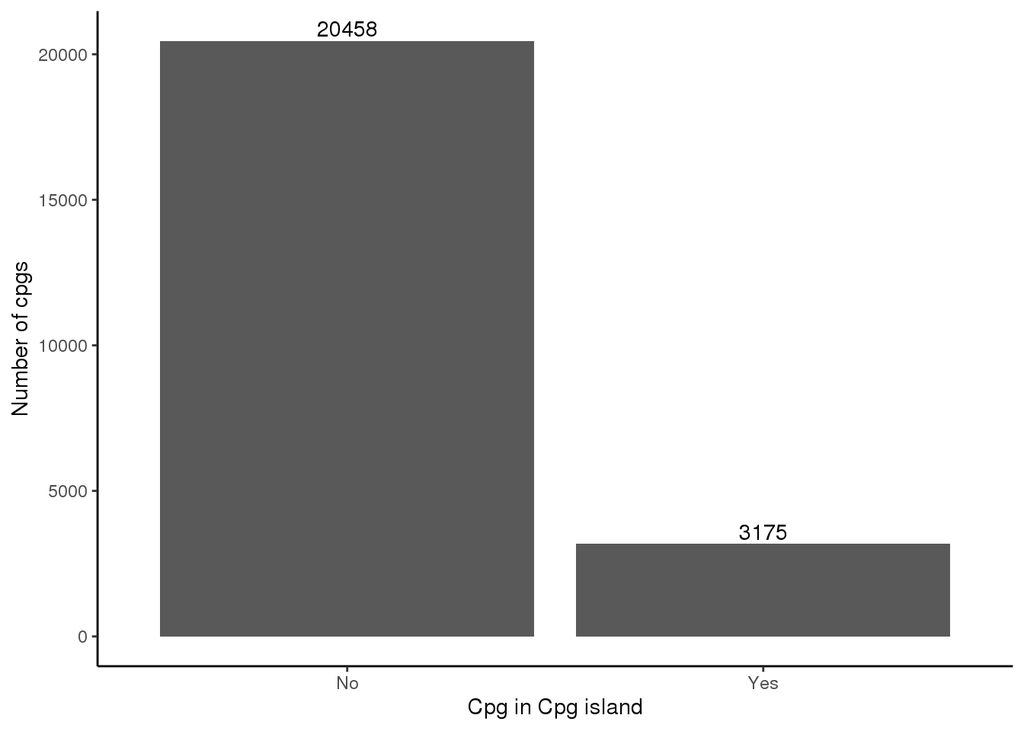

```r
par(mfrow = c(2,1))
ggplot(MouseCpg, aes(MouseCpg$Var1, MouseCpg$Freq))+
  geom_bar(stat = "identity") +
  labs(x = "Cpg in Cpg island", y = "Number of cpgs") +
  geom_text(aes(label=MouseCpg$Freq), position=position_dodge(width=0.9), vjust=-0.25) +
  theme_classic()
```

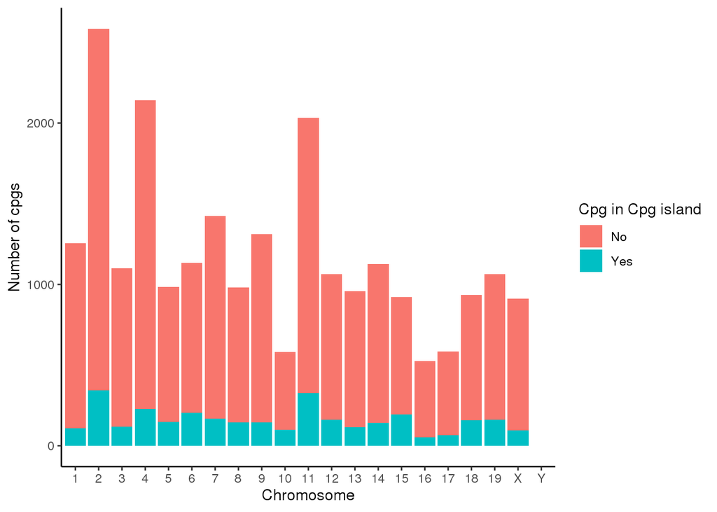

```r
tblmousecpg$Var1 <- factor(tblmousecpg$Var1, levels = chroder)
ggplot(tblmousecpg, aes(fill = tblmousecpg$Var2, x = tblmousecpg$Var1,
                        y =tblmousecpg$Freq)) +
  geom_bar(position="stack", stat="identity") +
  guides(fill=guide_legend(title="Cpg in Cpg island")) +
  labs(x = "Chromosome", y = "Number of cpgs") +
  theme_classic()
```

# Comparison to 450K & EPIC array

The vertebrate array shares some probes on the 450k and EPIC array. This table summaries the cpgs that are shared between the arrays.

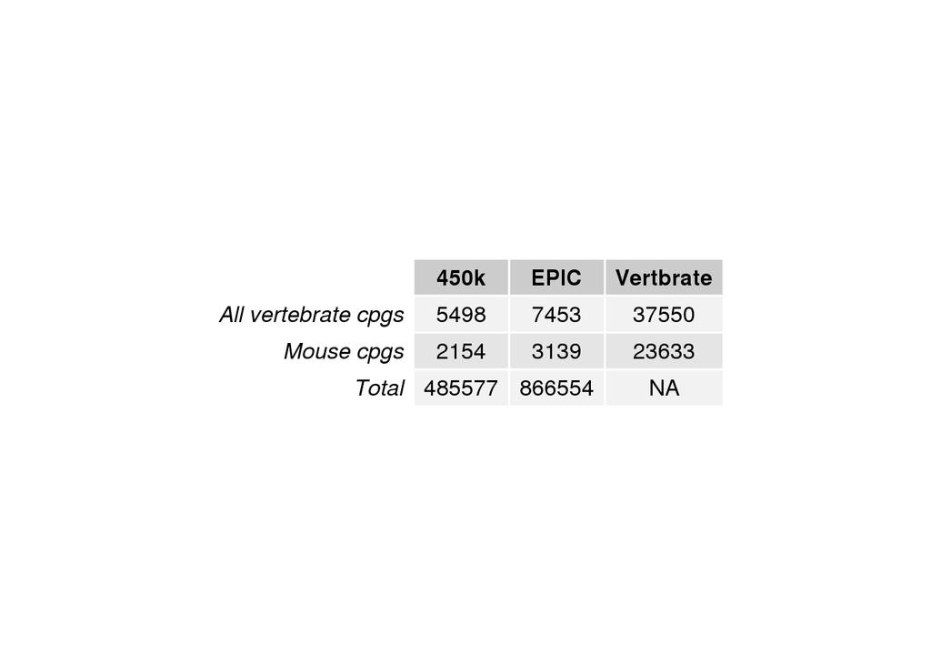

```r
load("/gpfs/ts0/projects/Research_Project-191406/Aisha/data/Array/AllProbeIlluminaAnno.Rdata")
EpicAnnot <- read.csv( "/gpfs/ts0/projects/Research_Project-191406/Aisha/data/Array/epicManifest_hg38.csv" ,stringsAsFactors = F, header = T)

#Make table with summary
overlapdf <- matrix(data = NA, nrow = 2, ncol = 2)
rownames(overlapdf) <- c("All vertebrate cpgs",
                         "Mouse cpgs")
colnames(overlapdf) <- c("450k", "EPIC")

#Overlap with vertebrate array
overlapdf[1,1] <- length(intersect(probe_mapping_file$probeID, probeAnnot$TargetID)) #5498 w/ 450k
overlapdf[1,2] <- length(intersect(probe_mapping_file$probeID, EpicAnnot$Name)) #7453 w/ EPIC

#Overlap with mouse cpgs
overlapdf[2,1] <- length(intersect(species_probes$probeID, probeAnnot$TargetID)) #2154 w/ 450k
overlapdf[2,2] <- length(intersect(species_probes$probeID, EpicAnnot$Name)) #3139 w/ EPIC



Total <- c(nrow(probeAnnot), nrow(EpicAnnot), NA)
Vertbrate    <- c(nrow(probe_mapping_file), nrow(species_probes))

overlapdf2 <- cbind(overlapdf, Vertbrate)
overlapdf2 <- rbind(overlapdf2, Total)

grid.table(overlapdf2)
```

# Species coverage

There are 192 species and each species has different number of probes on the array. This table and barplot summarises the numbers of probes shared on the array. There is also ~2,000 probes for the epigenetic clock calculations.

```r
library(kableExtra)
library(ggplot2)
#library(bsselectR)
library(gridExtra)

#make a table of number of probes per species
probe_mapping_file2 <-   probe_mapping_file[,2:193]
rownames(probe_mapping_file2) <- probe_mapping_file$probeID
speciessummary <- matrix(NA, nrow = ncol(probe_mapping_file2), ncol = 1)
rownames(speciessummary) <- colnames(probe_mapping_file2)
colnames(speciessummary) <- "Number of probes"
for(i in 1:ncol(probe_mapping_file2)) {
  species <- as.matrix(probe_mapping_file2[,i])
  species[,1] <- as.character(species[,1])
  colnames(species) <- colnames(probe_mapping_file2)[i]
  species <- species[!is.na(species),]
  speciessummary[i,1] <- length(species)
}


kable(speciessummary) %>%
  kable_styling() %>%
  scroll_box(width = "100%", height = "500px")
```

|  | Number of probes |
| --- | --- |
| AcanthochromisPolyacanthus | 163 |
| AcinonyxJubatus | 27901 |
| AiluropodaMelanoleuca | 27042 |
| AlligatorMississippiensis | 5893 |
| AmphilophusCitrinellus | 158 |
| AmphiprionOcellaris | 164 |
| AmphiprionPercula | 157 |
| AnabasTestudineus | 168 |
| AnasPlatyrhynchos | 5346 |
| AnolisCarolinensis | 3244 |
| AotusNancymaae | 29855 |
| ApteryxAustralis | 4953 |
| AquilaChrysaetosCanadensis | 5550 |
| AstatotilapiaCalliptera | 157 |
| AstyanaxMexicanus | 167 |
| BalaenopteraAcutorostrataScammoni | 24988 |
| BosIndicusXBosTaurus | 27003 |
| BosIndicus | 24701 |
| BosMutus | 26016 |
| BosTaurus | 27006 |
| BubalusBubalis | 26783 |
| CallithrixJacchus | 29771 |
| CallorhinchusMilii | 426 |
| CallorhinusUrsinus | 24703 |
| CamelusBactrianus | 25618 |
| CamelusDromedarius | 25966 |
| CamelusFerus | 24498 |
| CanisFamiliaris | 26673 |
| CanisLupusDingo | 27276 |
| CapraHircus | 27092 |

[output cut: 162 more lines]

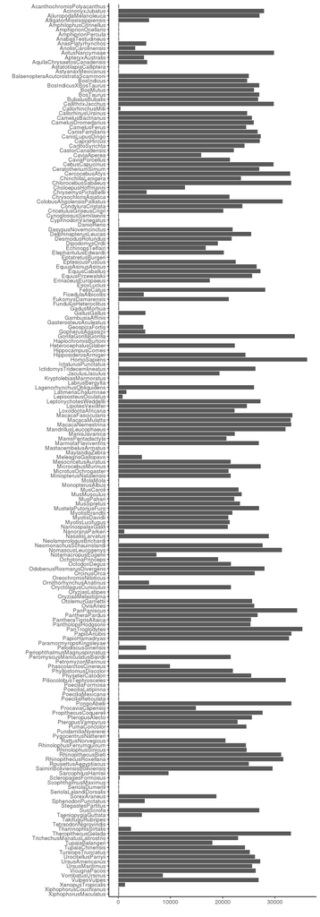

```r
# Make vertical barchart for species
speciessummary2 <- as.data.frame(speciessummary)
speciessummary2$species <- rownames(speciessummary2)
colnames(speciessummary2) <- c("Number_of_probes", "Species")
speciesorder <- sort(speciessummary2$Species, decreasing = T)
speciessummary2$Species <- factor(speciessummary2$Species,
                                    levels = speciesorder)

ggplot(speciessummary2, aes(x = speciessummary2$Species,
                           y = speciessummary2$Number_of_probes)) +
  geom_bar(stat = "identity") +
  labs(x = "", y = "") +
  coord_flip() +
  theme_classic()
```

# Distance between CpGs

There are a number of cpgs on the genome, and the distance varies for adjacent cpgs differs from region to region. Here, we calculate the distance (bps) between two adjacent cpgs for each chromosome. A histogram is plotted to visualise the distribution of these distances on each chromosome. The median for each chromosome is calculated and plotted to check that each chromosome is distributed similarly.

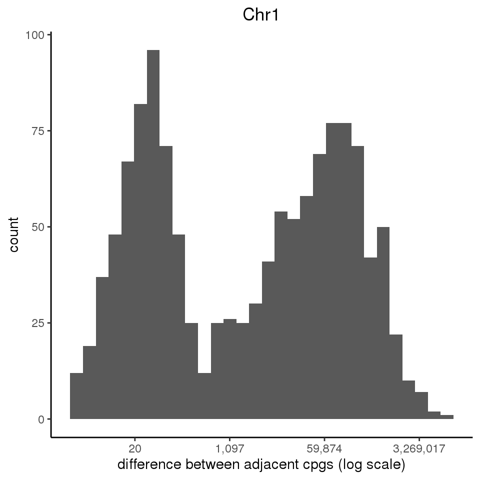

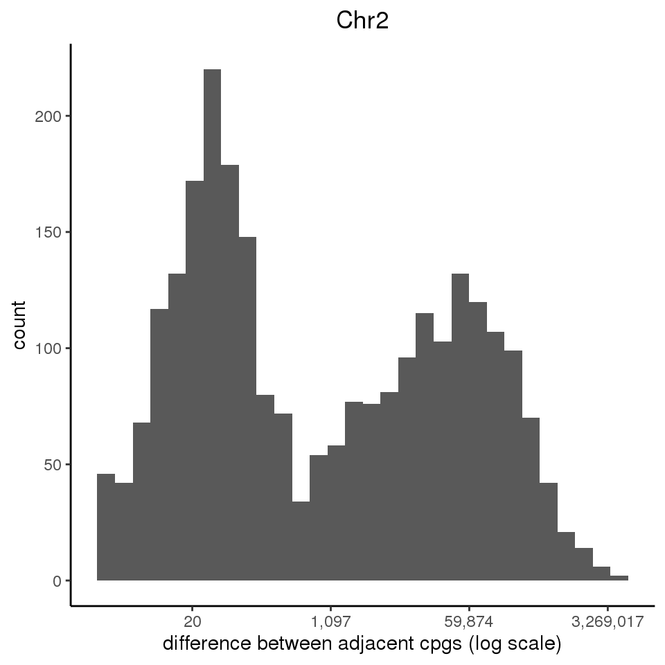

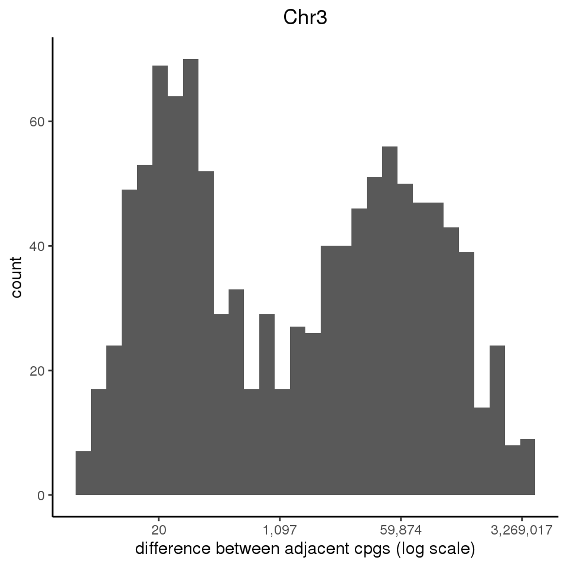

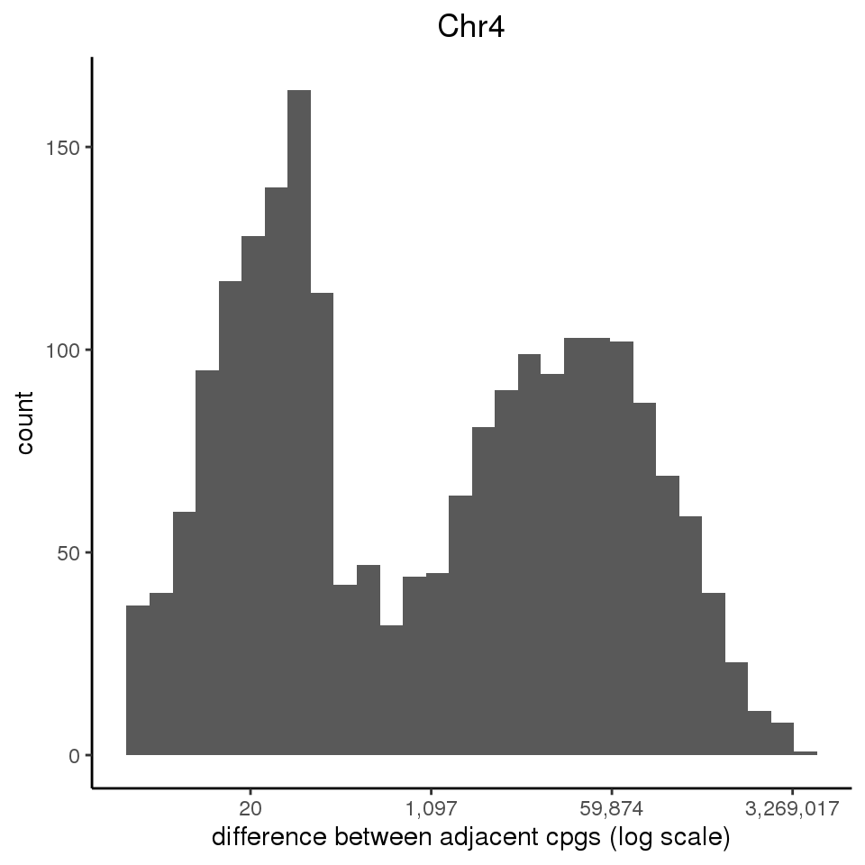

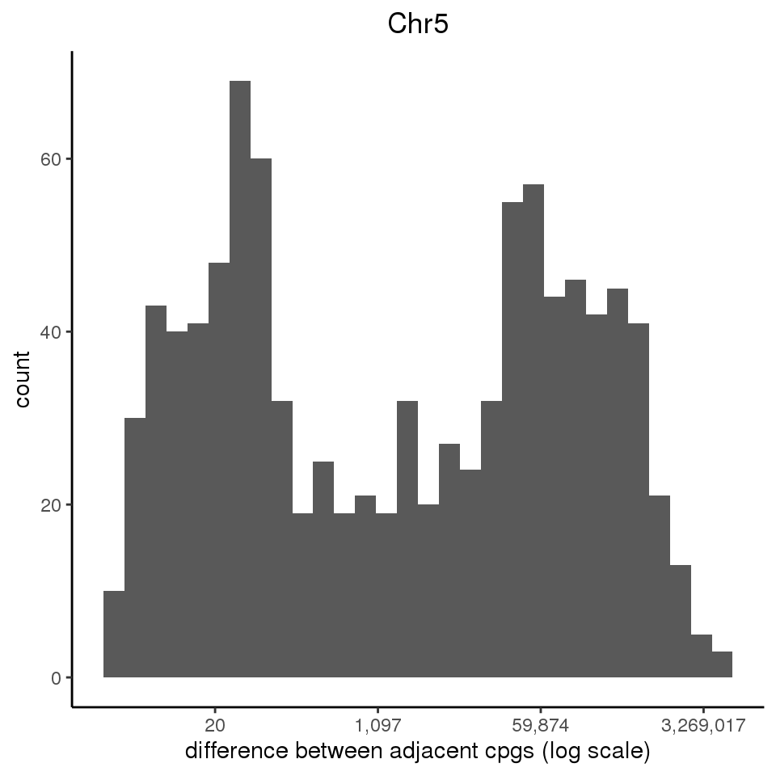

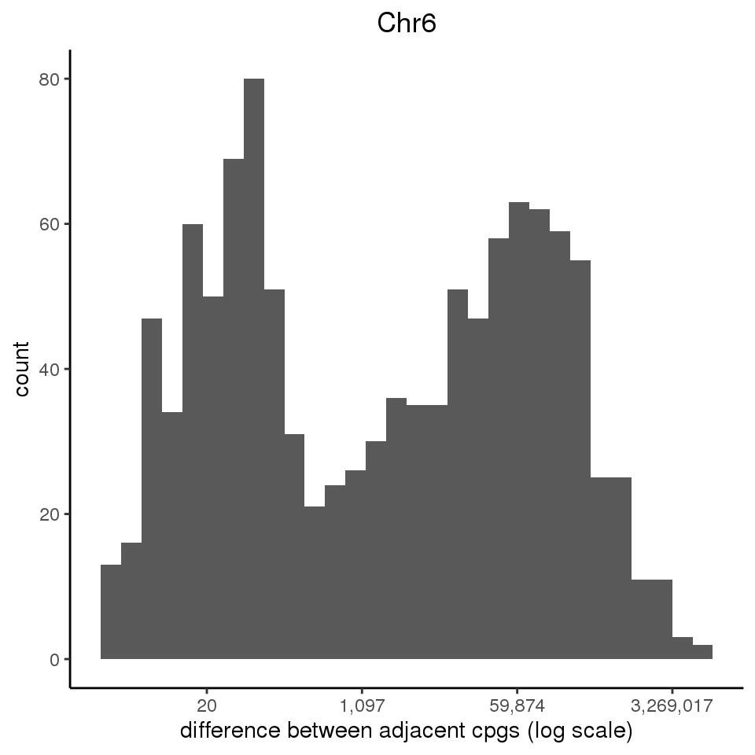

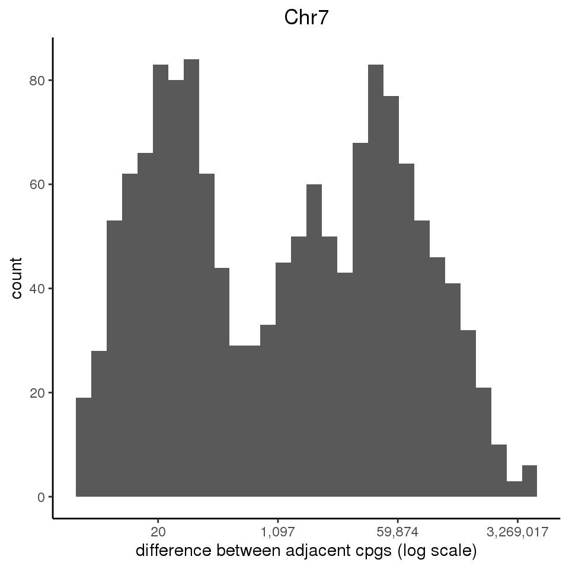

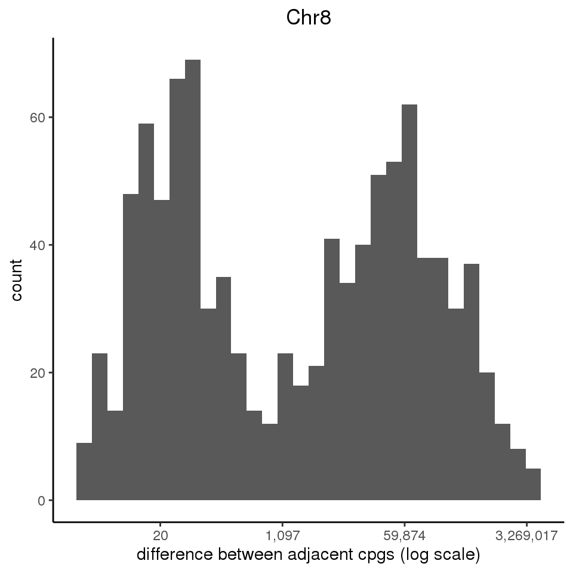

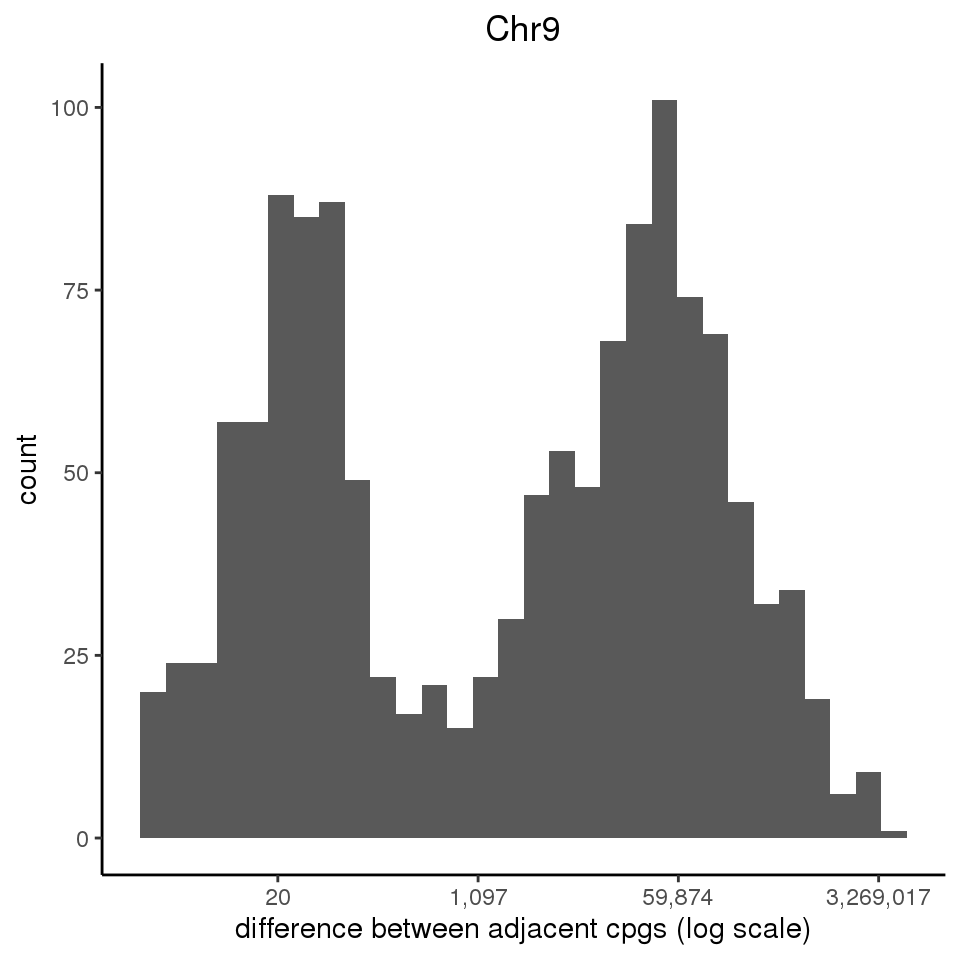

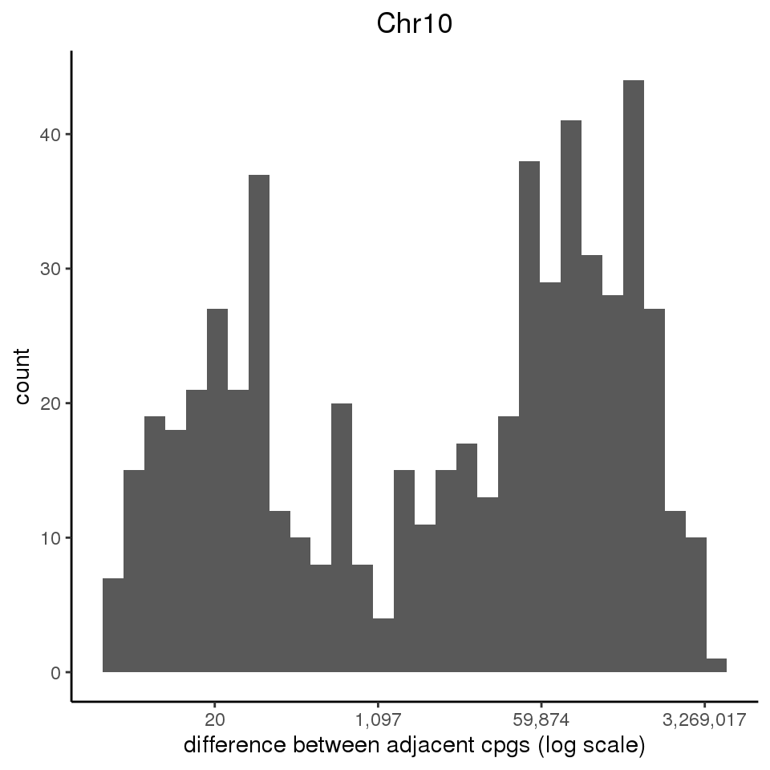

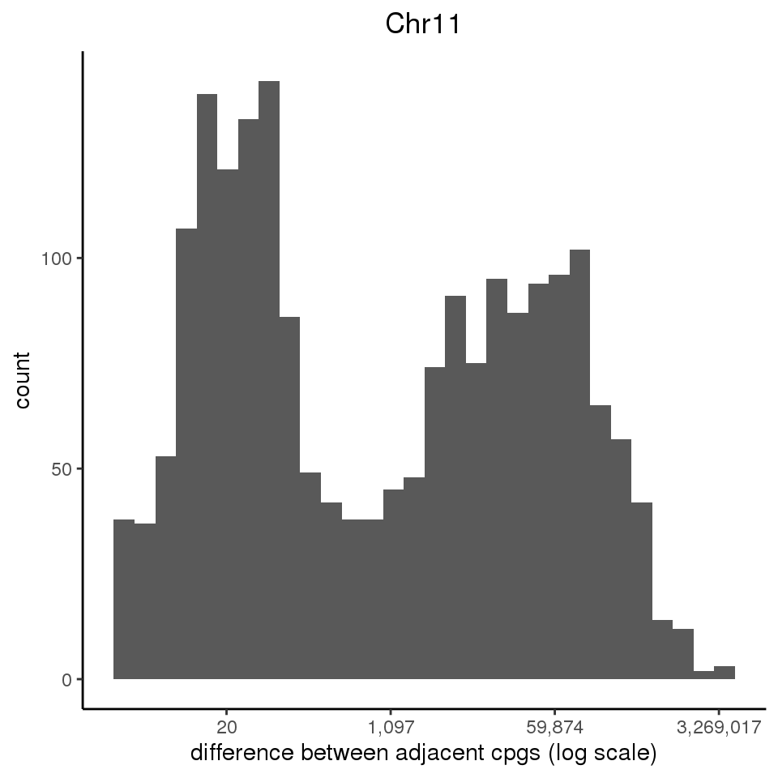

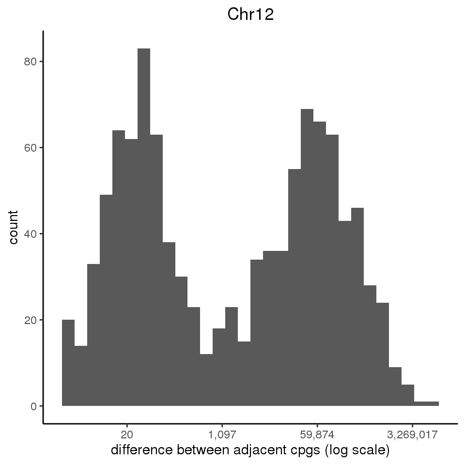

[8 more figures not shown]

```r
#"MusMusculus"
library(dplyr)
require(scales)
mouse <- as.data.frame(probe_mapping_file[, "MusMusculus"])
rownames(mouse) <- probe_mapping_file$probeID
colnames(mouse) <- "location"
mouse$location <- as.character(mouse$location)
mouse$Chr <- gsub(":.*", "", mouse$location)
mouse$Bp <- gsub(".*:", "", mouse$location)
mouse2 <- mouse[-which(mouse$Chr %in% c("CHR_MG51_PATCH" ,
                                     "CHR_MG4200_PATCH", "CHR_MG3699_PATCH")),]
chrs <- c(1:19, "X")
median_distance <- c()
for(i in chrs) {
  mouse2chr1 <- mouse[which(mouse$Chr == i),]
  mouse2chr1$Bp <- as.numeric(as.character(mouse2chr1$Bp))
  mouse2chr1 <- mouse2chr1[order(mouse2chr1$Bp), ]
  mouse2chr1 <- mouse2chr1 %>%
    mutate(Diff = Bp - lag(Bp)) #this works out the difference of cpgs on each chrs
  median_distance <- c(median_distance, median(mouse2chr1$Diff[2:nrow(mouse2chr1)]))

p = ggplot(mouse2chr1, aes(mouse2chr1$Diff)) +
    geom_histogram() +
    scale_x_continuous(labels = comma, trans='log') +
    scale_y_continuous(labels = comma) +
    theme_classic() +
    labs(x = "difference between adjacent cpgs (log scale)",
         title = paste("Chr",i, sep = "")) +
    theme(plot.title = element_text(hjust = 0.5))

print(p)
}
```

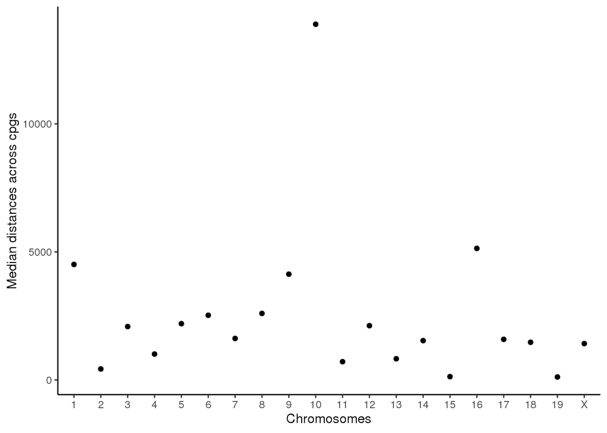

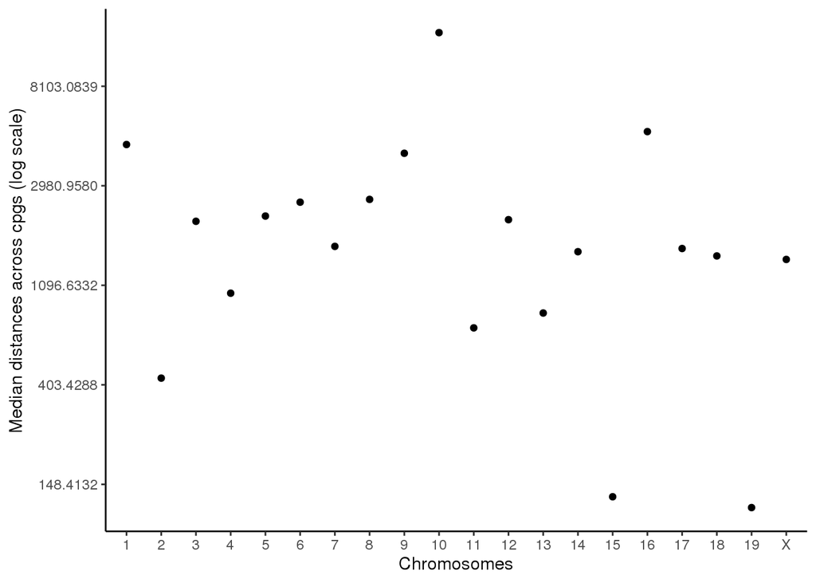

```r
median_distancedf <- data.frame(chrs, median_distance)
median_distancedf$chrs  <- as.character(median_distancedf$chrs)
ggplot(median_distancedf, aes(x = factor(median_distancedf$chrs, levels = chrs), y = median_distancedf$median_distance)) +
  geom_point() +
  labs(x = "Chromosomes", y = "Median distances across cpgs") +
  theme_classic()
ggplot(median_distancedf, aes(x = factor(median_distancedf$chrs, levels = chrs), y = median_distancedf$median_distance)) +
  geom_point() +
  labs(x = "Chromosomes", y = "Median distances across cpgs (log scale)") +
  theme_classic()+
  scale_y_continuous(trans='log')
```

# Gene Annotation

```r
library(ChIPseeker)
library(TxDb.Mmusculus.UCSC.mm10.knownGene)
library(clusterProfiler)
library(tidyverse)

txdb <- TxDb.Mmusculus.UCSC.mm10.knownGene

# peak can be granges object..
manifest <- species_probes
manifest$Chr <- gsub(":.*", "", manifest$MusMusculus)
manifest$Bp <- gsub(".*:", "", manifest$MusMusculus)
manifest <- manifest[-which(manifest$Chr %in% c("CHR_MG51_PATCH" ,
                                                "CHR_MG4200_PATCH", "CHR_MG3699_PATCH")),]
manifest$start <- manifest$Bp
manifest$end <- manifest$Bp
manifest$Chr <- paste("chr", manifest$Chr, sep = "")
rownames(manifest) <- manifest$probeID
manifest <- manifest[,-c(1:2)]
mm10_granges <- makeGRangesFromDataFrame(manifest,
                                         keep.extra.columns=T,
                                         ignore.strand=FALSE,
                                         seqinfo=NULL,
                                         seqnames.field=c("seqnames","seqname",
                                                          "chromosome", "chrom",
                                                          "chr", "chromosome_name"),
                                         start.field="start",
                                         end.field="end") #make this object to carry the liftover
peakAnno <- annotatePeak(mm10_granges,
                         TxDb=txdb, annoDb="TxDb.Mmusculus.UCSC.mm10.knownGene")
```

```
## >> preparing features information...      2020-08-25 05:27:05 PM
## >> identifying nearest features...        2020-08-25 05:27:06 PM
## >> calculating distance from peak to TSS...   2020-08-25 05:27:08 PM
## >> assigning genomic annotation...        2020-08-25 05:27:08 PM
## >> adding gene annotation...          2020-08-25 05:27:26 PM
## >> assigning chromosome lengths           2020-08-25 05:27:26 PM
## >> done...                    2020-08-25 05:27:26 PM
```

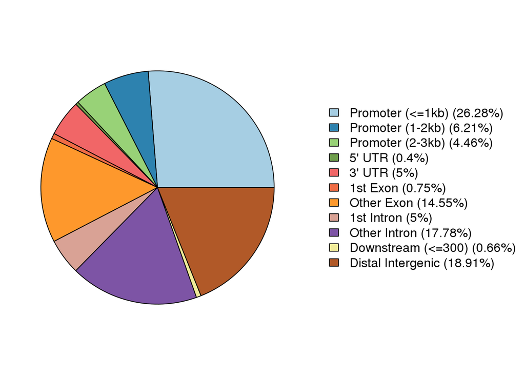

```r
plotAnnoPie(peakAnno)
```

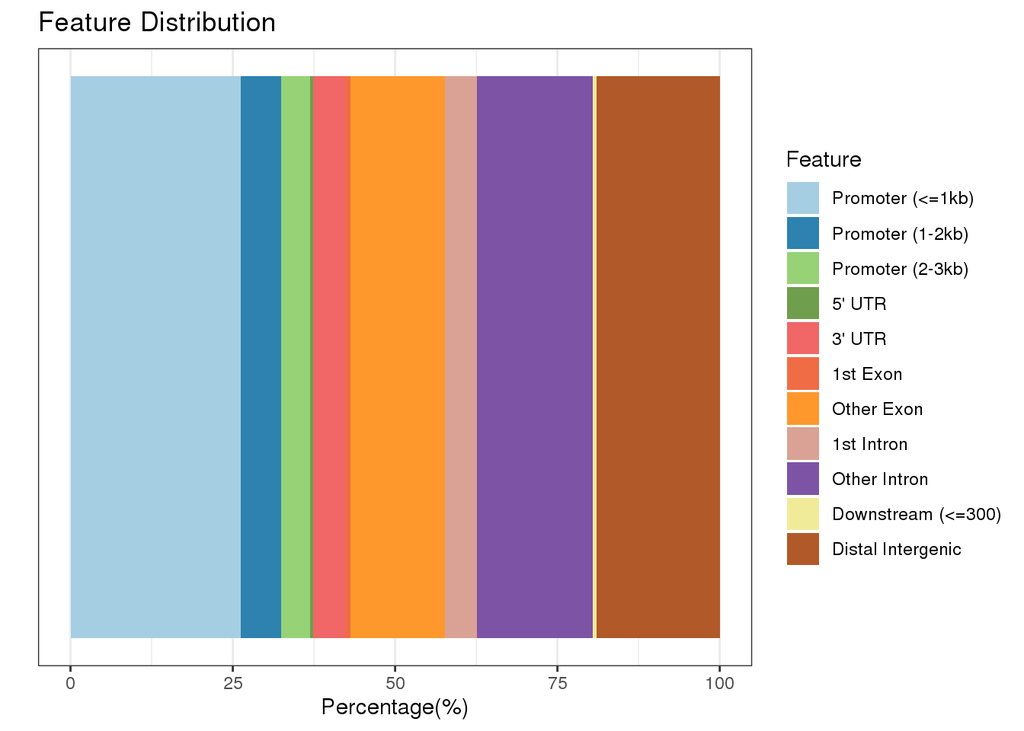

```r
plotAnnoBar(peakAnno)
```

```r
# Pull out the annotation
peakAnno_df <- as.data.frame(peakAnno@anno)

# Convert the ensemble id startto ensemble name
EnsembleID <- peakAnno_df$transcriptId

library('biomaRt')
mart <- useDataset("mmusculus_gene_ensembl", useMart("ensembl"))
G_list <- getBM(attributes = c('ensembl_transcript_id_version',
                               'ensembl_gene_id',
                               'external_transcript_name',
                               'external_gene_name'),
                filters = 'ensembl_transcript_id_version',
                values = EnsembleID,
                mart = mart)

write.csv(G_list, "Peak_transcript_Gene.csv")

peakAnno_df$Gene_Symbol <- rep(NA, nrow(peakAnno_df))

peakAnno_df$Gene_Symbol <- G_list$external_gene_name[match(peakAnno_df$transcriptId, G_list$ensembl_transcript_id_version)]


peakAnno_df$cpg <- rownames(peakAnno_df)
peakAnno_df <- peakAnno_df[,c(17,1:16)]

write.csv(peakAnno_df, "mm10_Manifest.csv")
```

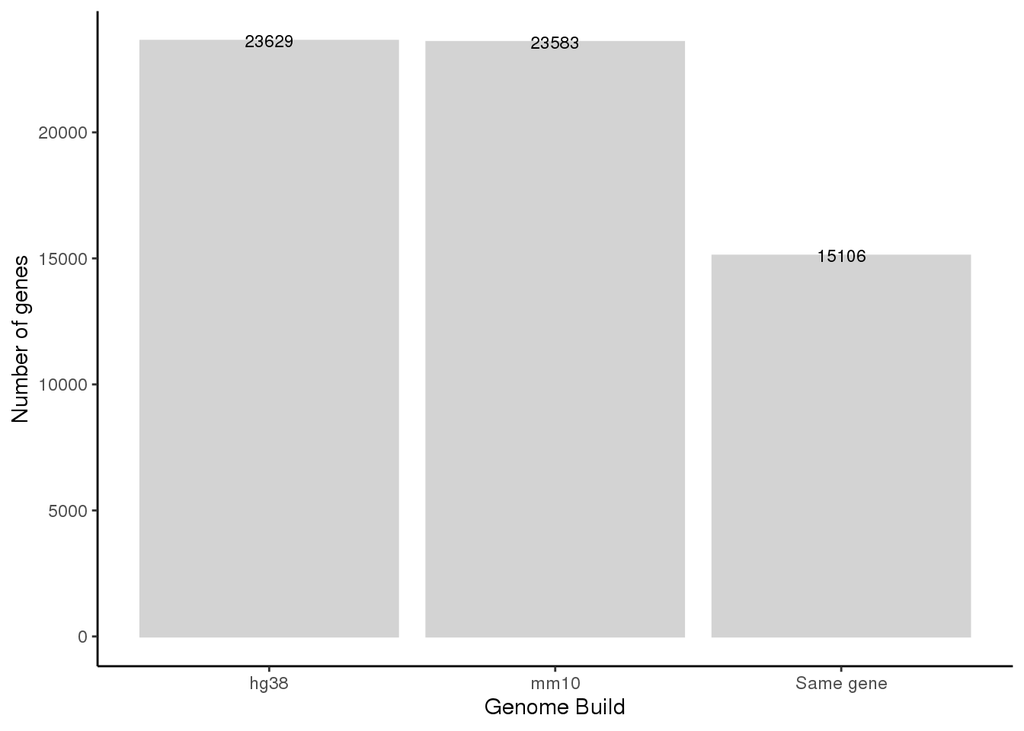

```r
library(stringr)
library(ggplot2)
library(reshape2)
library(tidyr)

ManifestHorvath <- read.csv("/gpfs/ts0/projects/Research_Project-191406/Horvath/MammalianArrayNormalizationTools/manifests/HorvathMammal40.Manifest.May2020.manifest.csv", stringsAsFactors = F, header = T)
Manifest <- read.csv("//gpfs/ts0/projects/Research_Project-191406/Aisha/data/Array/mm10_Manifest.csv", stringsAsFactors = F,header = T, row.names = 1)

#identical(ManifestHorvath$IlmnID, Manifest$cpg)

# Filter for the same probes
ManifestHorvath <- ManifestHorvath[which(ManifestHorvath$IlmnID %in% Manifest$cpg),]
#identical(ManifestHorvath$IlmnID, Manifest$cpg)


# Make different dataframe with probe and gene names
hg38 <- ManifestHorvath[,c("IlmnID", "HG38.SYMBOL")]
mm10 <- Manifest[,c("cpg", "Gene_Symbol")]
#identical(hg38$IlmnID, mm10$cpg) #same order -yes


############### First level - are the cpg annotated to the same gene
#remove caps
mm10$Gene_Symbol <- str_to_lower(mm10$Gene_Symbol, locale = "en")
hg38$HG38.SYMBOL <- str_to_lower(hg38$HG38.SYMBOL, locale = "en")

samegene <- matrix(NA, nrow = nrow(mm10),ncol = 4)
for(i in 1:nrow(samegene)){
  samegene[i,1] <- mm10[i,1] #cpg name
  samegene[i,2] <- grepl(hg38[i,2], mm10[i,2]) #TRUE/FALSE if both exists
  samegene[i,3] <- identical(hg38[i,2],mm10[i,2]) #Checks that its one to one gene labelling, false if mm10 has mulitple gene labelling
  samegene[i,4] <- pmatch(mm10[i,2] , hg38[i,2]) #partial match e.g abd-1 and abd is seen the same

}
samegene <- as.data.frame(samegene) #convert the vector to df
colnames(samegene) <- c("cpg", "Both_Genomes", "Identical", "Partial_Match")
#length(which(samegene$Both_Genomes == TRUE)) #14,744
#length(which(samegene$Both_Genomes == FALSE)) #8,884
#length(which(samegene$Partial_Match == 1))

gene_summary <- cbind(sum(!is.na(mm10$Gene_Symbol)),
                      sum(!is.na(hg38$HG38.SYMBOL)),
                      length(which(samegene$Both_Genomes == TRUE)),#How many sites had exact same genes to a site
                      length(which(samegene$Identical == TRUE))) #How many sites are identical 1:1
gene_summary <- as.data.frame(gene_summary)
colnames(gene_summary) <- c("mm10", "hg38", "Gene in both builds", "Same gene")

gene_summary <- gene_summary[,c(2,1,3,4)] #reorder here since df will be melted

mdf <- melt(gene_summary[,c(1,2,4)])
ggplot(mdf, aes(x = variable, y = value, label = value)) +
  geom_bar(stat = "identity", fill = "lightgrey", colour = "lightgrey") +
  labs(x = "Genome Build", y = "Number of genes") +
  theme_bw() +
  theme(panel.border = element_blank(), panel.grid.major = element_blank(),
        panel.grid.minor = element_blank(), axis.line = element_line(colour = "black")) +
  geom_text(position = position_dodge(width=0.9),
            size=3)
```

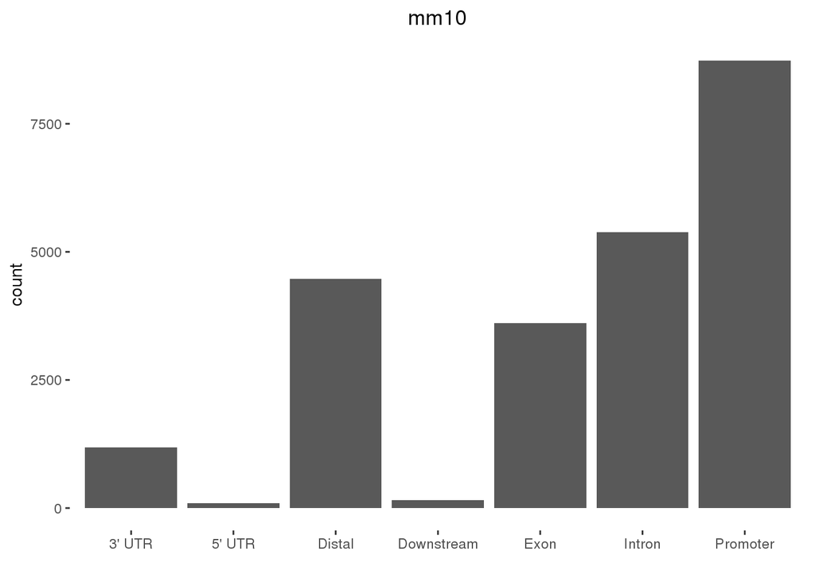

```r
############### Second level- are cpg annotated to the same feature of the same gene

## Find out what the annotation names are:
# Take the first word - make sure its 3'UTR not just 3
mm10$Annot <- Manifest$annotation
mm10$Annot2 <- gsub("([A-Za-z]+).*", "\\1", mm10$Annot)
mm10$Annot2 <- factor(mm10$Annot2, levels = c("3' UTR", "5' UTR" ,"Distal", "Downstream",
                                            "Exon","Intron","Promoter"))
## mm10
ggplot(mm10, aes(x = Annot2)) +
  geom_bar() +
  theme_bw() +
  theme(panel.border = element_blank(), panel.grid.major = element_blank(),
        panel.grid.minor = element_blank()) +
  theme(plot.title = element_text(hjust = 0.5)) +
  labs(x = "", title = "mm10")
```

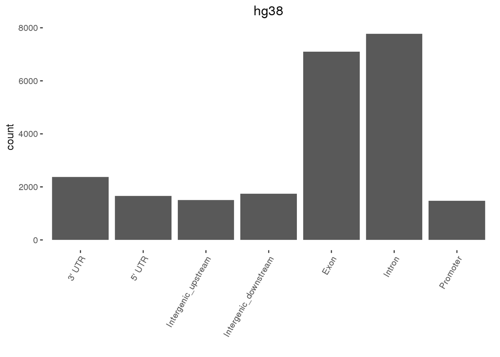

```r
# unique(ManifestHorvath$HG38.main_Categories)
ManifestHorvath$HG38.main_Categories[ManifestHorvath$HG38.main_Categories == "threeUTR"] <- "3' UTR"
ManifestHorvath$HG38.main_Categories[ManifestHorvath$HG38.main_Categories == "fiveUTR"] <- "5' UTR"
ManifestHorvath$HG38.main_Categories<- factor(ManifestHorvath$HG38.main_Categories,
                                              levels = c("3' UTR", "5' UTR" ,"Intergenic_upstream",
                                                         "Intergenic_downstream","Exon","Intron","Promoter"))
## hovarth
ggplot(ManifestHorvath, aes(x = HG38.main_Categories)) +
  geom_bar() +
  theme_bw() +
  theme(panel.border = element_blank(), panel.grid.major = element_blank(),
        panel.grid.minor = element_blank()) +
  theme(axis.text.x = element_text(angle = 60, hjust = 1), plot.title = element_text(hjust = 0.5)) +
  labs(x = "", title = "hg38")
```